# Homework_9

Cai McCann

3/25/2020

### Question 1:

Use the code that you worked on in Homework #7 (creating fake data sets) , and re-organize it following the principles of structured programming. Do all the work in a single chunk in your R markdown file, just as if you were writing a single R script. Start with all of your annotated functions, preliminary calls, and global variables. The program body should be only a few lines of code that call the appropriate functions and run them in the correct order. Make sure that the output from one function serves as the input to the next. You can either daisy-chain the functions or write separate lines of code to hold elements in temporary variables and pass the along.

```r
# ---------------------------------
# A single R script following the principles of structured programming
# description: to simulate data, conduct an ANOVA, and summarize results (statistics and graph)
# 26 March 2020
# CLM
# ---------------------------------
#

## PSEUDOCODE #######################################################################

# get_data() = generate a simulation of data for analysis
# calc_anova() = conducts ANOVA
# summarize_anova() = extracts ANOVA results
# graph_ano() = visualize results of analysis

#########################################################################

# Load libraries ---------------------------------------------------------

library(ggplot2)
library(dplyr)

# Global variables ---------------------------------------------------------

# specify group attributes
n_group <- 3 # number of groups
n_name <- c("Nonsmoking","Smoking","Formersmoking") # name the groups, these are essentially global variables
n_size <- c(707,175,355) # group sizes
n_mean <- c(25,28,28) # mean BMI value
n_sd<- c(6,6,6) # variance for each group


# Program functions ---------------------------------------------------------

# Part 1: get_data() function -----------------------------------------------------------
# ---------------------------------
#  FUNCTION get_data
#  description: simulates BMI value for 3 groups of various smoking status (smoking, nonsmoking, former)
#  inputs: vectorized values of number of groups, group names, sample size, means, and standard deviations
#  outputs: a dataframe comprising simulated data under a normal distribution (col = id, fake_data_lab, norm_val)
###################################
  get_data <- function(n_group=3,
                       n_name=c("Nonsmoking","Smoking","Formersmoking"),
                       n_size=c(707,175,355),
                       n_mean=c(25,28,28),
                       n_sd=c(6,6,6)) {
    # organize these data into a data frame with the appropriate structure
    fake_data_lab <- rep(n_name, n_size)
    id <- 1:(sum(n_size))
    norm_val <- c(rnorm(n=n_size[1],mean=n_mean[1],sd=n_sd[1]),
                 rnorm(n=n_size[2],mean=n_mean[2],sd=n_sd[2]),
                 rnorm(n=n_size[3],mean=n_mean[3],sd=n_sd[3]))
    my_data <- data.frame(id,fake_data_lab,norm_val)

return(my_data)
} # end of get_data
# ---------------------------------

# Part 2: calc_anova() function ---------------------------------------------------------
# ---------------------------------
#  FUNCTION calc_anova
#  description: conduct ANOVA on simulated data from get_data() function
#  inputs: my_data()'s dataframe containing individuals, smoking status, and BMI (col = id, fake_data_lab, norm_val)--specifically for col 2=fake_data_lab and col 3=norm_val
#  outputs: ANOVA results
###################################
  calc_anova <- function(data=my_data) {

    my_anova <- aov(data[,3] ~ data[,2], data=my_data)  # BMI by smoking status
                                                       # col 2=fake_data_lab and col 3=norm_val

    return(my_anova)
} # end of calc_anova
# ---------------------------------

# Part 3: summarize_anova() function ---------------------------------------------------------

# ---------------------------------
#  FUNCTION summarize_anova
#  description: extract output from ANOVA model
#  inputs: calc_anova()'s generated ANOVA model
#  outputs: ANOVA output table, especially the F statistic & p value
#################################### thanks to Sophie for explaining processes!
  summarize_anova <- function(output=my_anova) {

    x <- summary(output) # summarize ANOVA
    print(x)
    ls_anova <- list(F_stat=unlist(x)[7], p_val=unlist(x)[9]) # extract F and pval
    print(ls_anova)

} # end of summarize_anova
# ---------------------------------

# Part 4: graph_ano() ---------------------------------------------------------

# ---------------------------------
#  FUNCTION graph_ano()
#  description: visualize the simulated data (BMI by smoking status), specifically as a boxplot
#  inputs: get_data() function's outputs of a dataframe containing id, smoking status, and BMI
#  outputs: boxplot (BMI by smoking status)
###################################
 graph_ano <- function(data=my_data) {
    p_ano <- ggplot(data=my_data,
                     aes(x=fake_data_lab,
                         y=norm_val,
                         fill=fake_data_lab)) +
    geom_boxplot() +
    labs(title='BMI by smoking status',
         x='Smoking status',
         y='BMI') +
    guides(fill=FALSE) # removed legend because redundant

    print(p_ano)
} # end of graph_ano()
# ---------------------------------

# Program body ---------------------------------------------------------

my_data <- get_data()

my_anova <- calc_anova(data=my_data)

summary_anova <- summarize_anova(output=my_anova)
```

```
##               Df Sum Sq Mean Sq F value   Pr(>F)
## data[, 2]      2   2614  1306.8   36.04 6.15e-16 ***
## Residuals   1234  44749    36.3
## ---
## Signif. codes:  0 '***' 0.001 '**' 0.01 '*' 0.05 '.' 0.1 ' ' 1
## $F_stat
## F value1
## 36.03741
##
## $p_val
##     Pr(>F)1
## 6.15409e-16
```

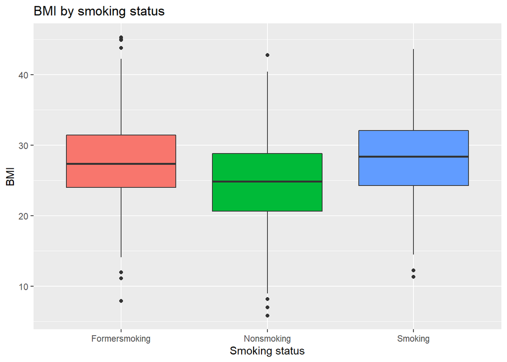

```r
my_graph <- graph_ano(data=my_data)
```

### Question 2:

Once your code is up and working, modify your program do something else: record a new summary variable, code a new statistical analysis, or create a different set of random variables or output graph. Do not rewrite any of your existing functions. Instead, copy them, rename them, and then modify them to do new things. Once your new functions are written, add some more lines of program code, calling a mixture of your previous functions and your new functions to get te job done.

*I was curious about visualizing the distributions of BMI by smoking status in an alternate way, overlapping histograms. I like how the histograms display skew in another helpful way for viewers to conceptualize and also show the relative counts among differen smoking statuses.*

```r
# ---------------------------------
# A **modified* single R script following the principles of structured programming
# description: to simulate data, conduct an ANOVA, and summarize results (statistics and graph)
# 26 March 2020
# CLM
# ---------------------------------


## PSEUDOCODE ####################################################################

# get_data() = generate a simulation of data for analysis
# calc_anova() = conducts ANOVA
# summarize_anova() = extracts ANOVA results
# graph_hist() = visualize results of analysis **as histograms**

#########################################################################

# *For brevity, assume the initial set up and some details on functions are similar to the original version of the structured programming

# Program functions ---------------------------------------------------------

#  FUNCTION get_data
  get_data2 <- function(n_group=3,
                       n_name=c("Nonsmoking","Smoking","Formersmoking"),
                       n_size=c(707,175,355),
                       n_mean=c(25,28,28),
                       n_sd=c(6,6,6)) {
    fake_data_lab <- rep(n_name, n_size)
    id <- 1:(sum(n_size))
    norm_val <- c(rnorm(n=n_size[1],mean=n_mean[1],sd=n_sd[1]),
                 rnorm(n=n_size[2],mean=n_mean[2],sd=n_sd[2]),
                 rnorm(n=n_size[3],mean=n_mean[3],sd=n_sd[3]))
        my_data2 <- data.frame(id,fake_data_lab,norm_val)
return(my_data2)
}
#  FUNCTION calc_anova
  calc_anova2 <- function(data=my_data2) {
    my_anova2 <- aov(data[,3] ~ data[,2], data=my_data2)
    return(my_anova2)
}

#  FUNCTION summarize_anova
  summarize_anova2 <- function(output=my_anova2) {
    y <- summary(output)
    print(y)
    ls_anova2 <- list(F_stat=unlist(y)[7], p_val=unlist(y)[9])
    print(ls_anova2)
}

# new graph function called graph_hist()-------------------------------------------

# ---------------------------------
#  FUNCTION graph_hist()
#  description: visualize the simulated data (BMI by smoking status), specifically as **overlapping histograms**
#  inputs: get_data2() function's outputs of a dataframe containing id, smoking status, and BMI
#  outputs: histogram (BMI by smoking status)
###################################
graph_hist <- function(data=my_data2) {
  # ggplot (data = my_data,
  #       mapping = aes(x = norm_val)) +
  #  geom_histogram(fill = fake_data_lab)

   my_hist <- ggplot(data=my_data2,
                       aes(x=norm_val)) + # distribution of BMI
         geom_histogram(aes(fill=factor(fake_data_lab)), bins=50, # tighter bin #s
                   alpha=0.5) + # make 50% transparent since multiple histograms
     # clean up labels on the graph
     labs(title='Distributions of BMI by Smoking Status',
          x='BMI',
          fill='Smoking status')
       print(my_hist)
} # end of graph_hist()
# ---------------------------------


# Program body ---------------------------------------------------------

my_data2 <- get_data2()

my_anova2 <- calc_anova2(data=my_data2)

summary_anova2 <- summarize_anova2(output=my_anova2)
```

```
##               Df Sum Sq Mean Sq F value  Pr(>F)
## data[, 2]      2   1937   968.7   27.15 2.9e-12 ***
## Residuals   1234  44031    35.7
## ---
## Signif. codes:  0 '***' 0.001 '**' 0.01 '*' 0.05 '.' 0.1 ' ' 1
## $F_stat
## F value1
## 27.14736
##
## $p_val
##      Pr(>F)1
## 2.897729e-12
```

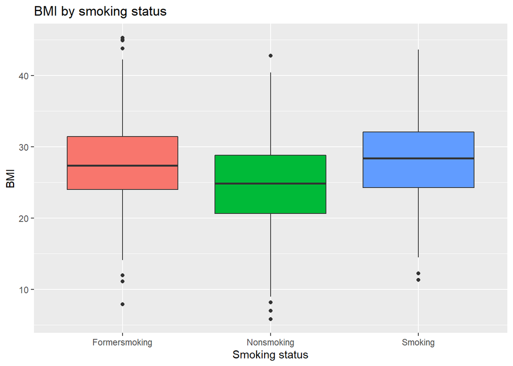

```r
my_graph <- graph_ano(data=my_data2)
```

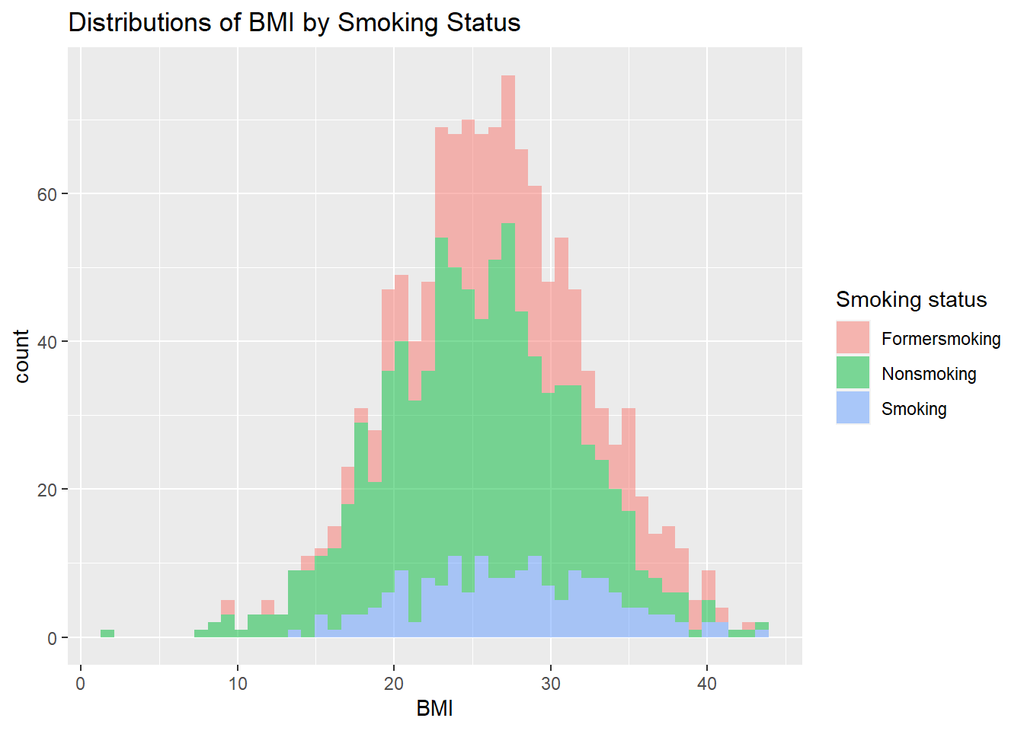

```r
my_graph2 <- graph_hist(data=my_data2)
```